# A Report of Delayed Flights in NYC Airports

By Sabrina Sayasith and Grace Zhan

2/9/16

We chose to visualize the flights data set from the nycflights13 package. A detailed description of the data and its variables can be found here: http://www.rdocumentation.org/packages/nycflights13/functions/flights Our graphics focus on departure delays of flights.

```r
require(mosaic)
require(ggplot2)
require(scales)
require(nycflights13)
data(flights)
```

We altered the data to include a new variable called isDelayed. isDelayed reports a value of either TRUE or FALSE. TRUE means that the departure of the flight was delayed by 1 or more minutes. We then created the variable numDelayed representing the total number of flights delayed and the variable delay_pct representing the percentage of all flights that have isDelayed set to TRUE.

```r
 flights<- flights%>%
     mutate(isDelayed=dep_delay>0)
 by_month <- flights %>%
     group_by(month) %>%
     summarize(N = n(), numDelayed = sum(isDelayed, na.rm = TRUE)) %>%
     mutate(delay_pct = numDelayed / N)
```

Our initial question was whether more flights were delayed in one month vs. another. As the weather changes, do we see a slow buildup of more flights delayed or do a couple of months stick out? What is the best month to travel without being delayed?

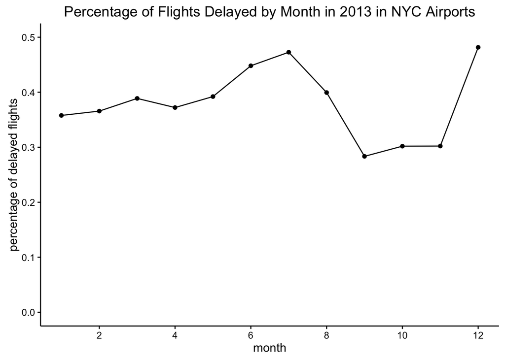

```r
p<-ggplot(data=by_month,aes(x=month,y=delay_pct))
p+geom_line(color="black")+geom_point(color="black")+scale_x_continuous(breaks= pretty_breaks(scn=12))+ggtitle("Percentage of Flights Delayed by Month in 2013 in NYC Airports") + labs(x="month",y="percentage of delayed flights") + theme(plot.title = element_text(family = "Trebuchet MS", color="#666666", face="bold", size=12, hjust=0)) + theme(axis.title = element_text(family = "Trebuchet MS", color="#666666", face="bold", size=12))+theme_classic()+coord_cartesian(ylim=c(0,0.5))
```

In our graphic, we see that starting in month 4, April, more and more flights become delayed each month until a peak is reached in month 7, July. After July, there is a sharp decline in the percentage of flights being delayed up until month 9, September. September has the lowest percentage of flights delayed, and it is also the start of fall.

July and December(month 12) have the highest percentage of flights delayed. December may have such a high percentage of delays because it is the holiday season and there also may be inclement weather due to winter time. July may have many delays because it is the start of the summer season.

```r
flights<- flights%>%
     mutate(isDelayed=dep_delay>0)
 by_origin <- flights %>%
     group_by(origin) %>%
     summarize(N = n(), numDelayed = sum(isDelayed, na.rm = TRUE)) %>% mutate(delay_pct = numDelayed / N)
```

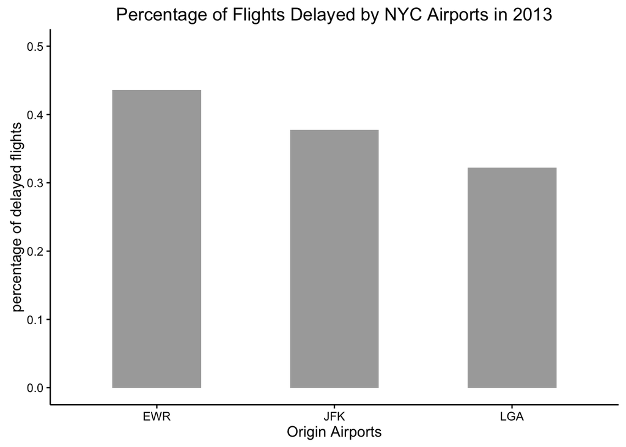

```r
g<-ggplot(data=by_origin,aes(x=origin,y=delay_pct))
g+geom_bar(stat="identity",fill="dark grey",size=1,width=0.5)+coord_cartesian(ylim=c(0,0.5))+ggtitle("Percentage of Flights Delayed by NYC Airports in 2013") + labs(x="Origin Airports",y="percentage of delayed flights") + theme(plot.title = element_text(family = "Trebuchet MS", color="#666666", face="bold", size=12, hjust=0)) + theme(axis.title = element_text(family = "Trebuchet MS", color="#666666", face="bold", size=12))+theme_classic()
```

Next, we wanted to know if one airport tended to have significantly more delays than the others. We see that the percentages of delayed flights for all 3 airports are pretty close. EWR, Newark Airport, had the highest percentage of delayed flights by a small margin.

```r
flights<- flights%>%
     mutate(isDelayed=dep_delay>0)
by_carrier <- flights %>%
     group_by(carrier) %>%
     summarize(N = n(), numDelayed = sum(isDelayed, na.rm = TRUE)) %>% mutate(delay_pct = numDelayed / N)
```

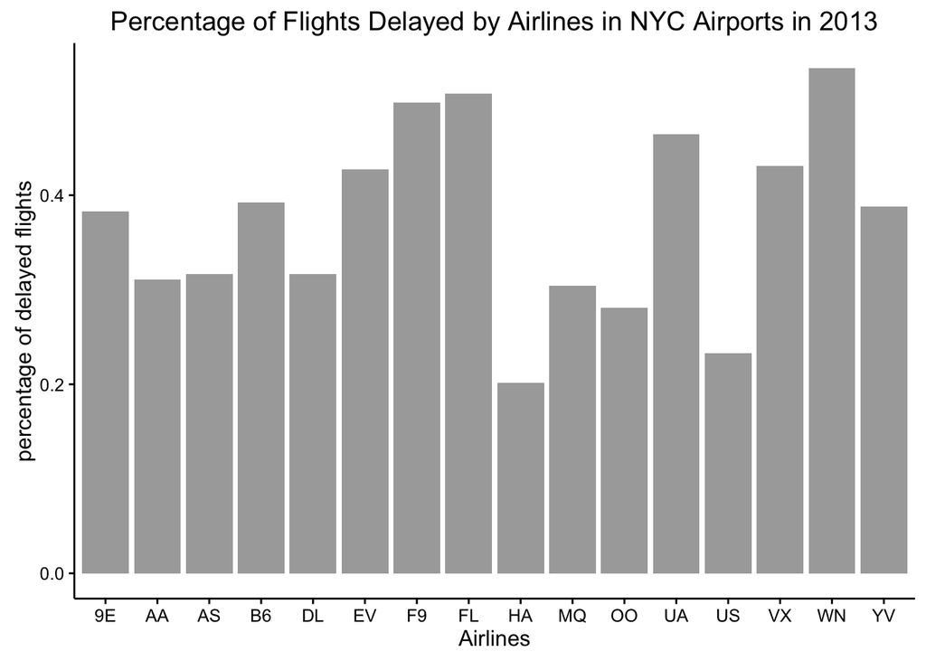

```r
f<-ggplot(data=by_carrier,aes(x=carrier,y=delay_pct))
f+geom_bar(stat="identity",fill="dark grey")+ggtitle("Percentage of Flights Delayed by Airlines in NYC Airports in 2013") + labs(x="Airlines",y="percentage of delayed flights") + theme(plot.title = element_text(family = "Trebuchet MS", color="#666666", face="bold", size=12, hjust=0)) + theme(axis.title = element_text(family = "Trebuchet MS", color="#666666", face="bold", size=12))+theme_classic()
```

We then wondered if the choice of airline carrier significantly impacted the chance of having a delayed flight. WN, Southwest Airlines, had the highest percentage of flights delayed. HA, Hawaiian Airlines, had the lowest percentage of flights delayed. The percentages of flights delayed varied widely across the different airlines.